# Regresiones lineales e interacciones

## Calculemos

\[ \begin{aligned} \operatorname{weight} &= 10.92 + 8.75(\operatorname{Time}) + 16.17(\operatorname{Diet}_{\operatorname{2}}) + 36.5(\operatorname{Diet}_{\operatorname{3}})\ + \\ &\quad 30.23(\operatorname{Diet}_{\operatorname{4}}) + \epsilon \end{aligned} \]

| Time | 0 | 0 | 4 | 4 |
| --- | --- | --- | --- | --- |
| Diet | 1 | 4 | 1 | 4 |

```r
(8.75 * 0) + 10.92 + (0 * 16.17) + (0 * 36.5) + (0 *
    30.23)
```

```
## [1] 10.92
```

```r
(8.75 * 0) + 10.92 + (0 * 16.17) + (0 * 36.5) + (1 *
    30.23)
```

```
## [1] 41.15
```

```r
(8.75 * 4) + 10.92 + (0 * 16.17) + (0 * 36.5) + (0 *
    30.23)
```

```
## [1] 45.92
```

```r
(8.75 * 4) + 10.92 + (0 * 16.17) + (0 * 36.5) + (1 *
    30.23)
```

```
## [1] 76.15
```

## Cambio Pendiente pero no intercepto

```r
fit2 <- lm(weight ~ Time + Time:Diet, data = ChickWeight)
```

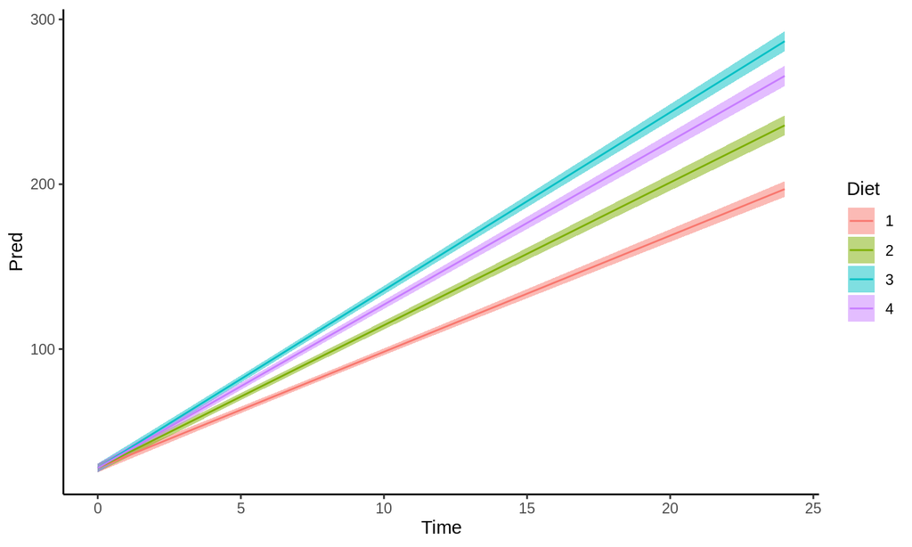

## Parametros

| term | estimate | std.error | statistic | p.value |
| --- | --- | --- | --- | --- |
| (Intercept) | 27.858834 | 2.6596172 | 10.474753 | 0e+00 |
| Time | 7.049161 | 0.2573403 | 27.392373 | 0e+00 |
| Time:Diet2 | 1.611209 | 0.3043700 | 5.293588 | 2e-07 |
| Time:Diet3 | 3.738317 | 0.3043700 | 12.282147 | 0e+00 |
| Time:Diet4 | 2.861438 | 0.3085932 | 9.272523 | 0e+00 |

## Calculemos

\[ \begin{aligned} \operatorname{weight} &= 27.86 + 7.05(\operatorname{Time}) + 1.61(\operatorname{Time} \times \operatorname{Time}_{\operatorname{Diet2}}) + 3.74(\operatorname{Time} \times \operatorname{Time}_{\operatorname{Diet3}})\ + \\ &\quad 2.86(\operatorname{Time} \times \operatorname{Time}_{\operatorname{Diet4}}) + \epsilon \end{aligned} \]

- Nuevos datos

| Time | Diet |
| --- | --- |
| 3 | 1 |
| 4 | 4 |

```r
(7.05 * 3) + (3 * 0 * 1.61) + (3 * 0 * 3.74) + (3 *
    0 * 2.86) + 27.86
```

```
## [1] 49.01
```

```r
(7.05 * 4) + (4 * 0 * 1.61) + (4 * 0 * 3.74) + (4 *
    1 * 2.86) + 27.86
```

```
## [1] 67.5
```

## Dudas?

## Cambio Pendiente e intercepto

```r
fit3 <- lm(weight ~ Time * Diet, data = ChickWeight)
```

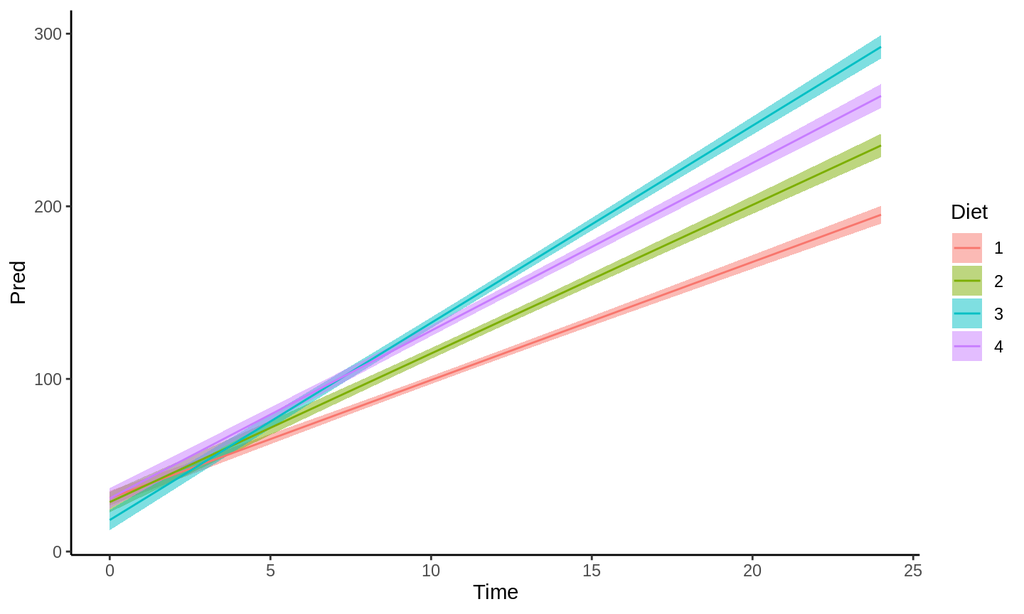

## Parametros

| term | estimate | std.error | statistic | p.value |
| --- | --- | --- | --- | --- |
| (Intercept) | 30.9309803 | 4.2468279 | 7.2833138 | 0.0000000 |
| Time | 6.8417972 | 0.3407938 | 20.0760630 | 0.0000000 |
| Diet2 | -2.2973848 | 7.2672309 | -0.3161293 | 0.7520201 |
| Diet3 | -12.6806551 | 7.2672309 | -1.7449088 | 0.0815397 |
| Diet4 | -0.1388608 | 7.2864589 | -0.0190574 | 0.9848020 |
| Time:Diet2 | 1.7673391 | 0.5716680 | 3.0915481 | 0.0020885 |
| Time:Diet3 | 4.5810738 | 0.5716680 | 8.0135216 | 0.0000000 |
| Time:Diet4 | 2.8725684 | 0.5781161 | 4.9688434 | 0.0000009 |

## Calculemos

\[ \begin{aligned} \operatorname{weight} &= 30.93 + 6.84(\operatorname{Time}) - 2.3(\operatorname{Diet}_{\operatorname{2}}) - 12.68(\operatorname{Diet}_{\operatorname{3}})\ - \\ &\quad 0.14(\operatorname{Diet}_{\operatorname{4}}) + 1.77(\operatorname{Time} \times \operatorname{Diet}_{\operatorname{2}}) + 4.58(\operatorname{Time} \times \operatorname{Diet}_{\operatorname{3}}) + 2.87(\operatorname{Time} \times \operatorname{Diet}_{\operatorname{4}})\ + \\ &\quad \epsilon \end{aligned} \]

| Time | Diet |
| --- | --- |
| 3 | 1 |
| 4 | 4 |

```r
(6.84 * 3) + (3 * 0 * 1.77) + (3 * 0 * 4.58) + (3 *
    0 * 2.87) + 30.93 + (-2.3 * 0) + (-12.7 * 0) +
    (-0.14 * 0)
```

```
## [1] 51.45
```

```r
(6.84 * 4) + (4 * 0 * 1.77) + (4 * 0 * 4.58) + (4 *
    1 * 2.87) + 30.93 + (-2.3 * 0) + (-12.7 * 0) +
    (-0.14 * 1)
```

```
## [1] 69.63
```

## CO2

| Plant | Type | Treatment | conc | uptake |
| --- | --- | --- | --- | --- |
| Qn1 | Quebec | nonchilled | 95 | 16.0 |
| Qn1 | Quebec | nonchilled | 175 | 30.4 |
| Qn1 | Quebec | nonchilled | 250 | 34.8 |
| Qn1 | Quebec | nonchilled | 350 | 37.2 |
| Qn1 | Quebec | nonchilled | 500 | 35.3 |
| Qn1 | Quebec | nonchilled | 675 | 39.2 |
| Qn1 | Quebec | nonchilled | 1000 | 39.7 |
| Qn2 | Quebec | nonchilled | 95 | 13.6 |
| Qn2 | Quebec | nonchilled | 175 | 27.3 |
| Qn2 | Quebec | nonchilled | 250 | 37.1 |
| Qn2 | Quebec | nonchilled | 350 | 41.8 |
| Qn2 | Quebec | nonchilled | 500 | 40.6 |
| Qn2 | Quebec | nonchilled | 675 | 41.4 |
| Qn2 | Quebec | nonchilled | 1000 | 44.3 |
| Qn3 | Quebec | nonchilled | 95 | 16.2 |
| Qn3 | Quebec | nonchilled | 175 | 32.4 |
| Qn3 | Quebec | nonchilled | 250 | 40.3 |
| Qn3 | Quebec | nonchilled | 350 | 42.1 |
| Qn3 | Quebec | nonchilled | 500 | 42.9 |
| Qn3 | Quebec | nonchilled | 675 | 43.9 |
| Qn3 | Quebec | nonchilled | 1000 | 45.5 |
| Qc1 | Quebec | chilled | 95 | 14.2 |
| Qc1 | Quebec | chilled | 175 | 24.1 |
| Qc1 | Quebec | chilled | 250 | 30.3 |
| Qc1 | Quebec | chilled | 350 | 34.6 |
| Qc1 | Quebec | chilled | 500 | 32.5 |
| Qc1 | Quebec | chilled | 675 | 35.4 |
| Qc1 | Quebec | chilled | 1000 | 38.7 |
| Qc2 | Quebec | chilled | 95 | 9.3 |
| Qc2 | Quebec | chilled | 175 | 27.3 |

[output cut: 54 more lines]

## Como se ve

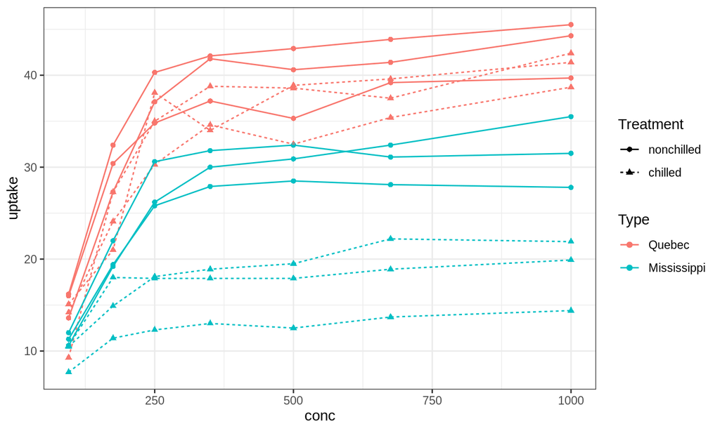

## Forma

## Forma

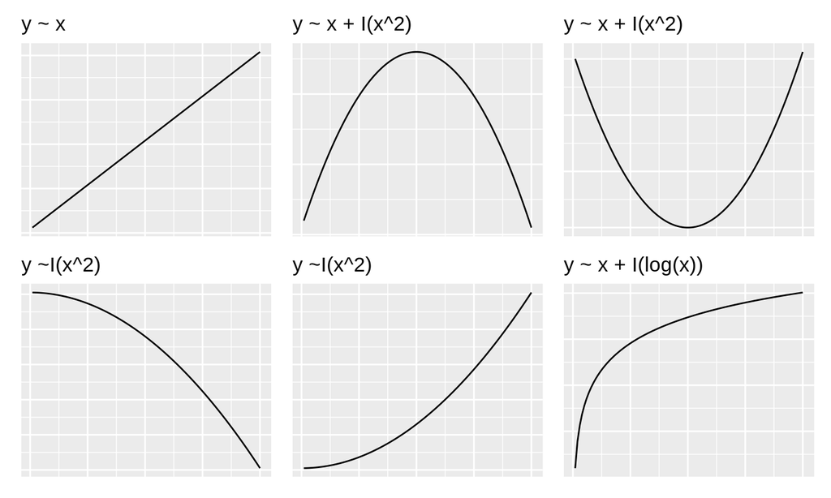

## A que se parece?

## CO2

```r
Model <- lm(uptake ~ conc + I(log(conc)) + Treatment +
    Type, data = CO2)
```

| term | estimate | std.error | statistic | p.value |
| --- | --- | --- | --- | --- |
| (Intercept) | -55.608 | 9.101 | -6.110 | 0 |
| conc | -0.025 | 0.005 | -5.201 | 0 |
| I(log(conc)) | 17.789 | 1.894 | 9.390 | 0 |
| Treatmentchilled | -6.860 | 0.935 | -7.337 | 0 |
| TypeMississippi | -12.660 | 0.935 | -13.541 | 0 |

## Veamos

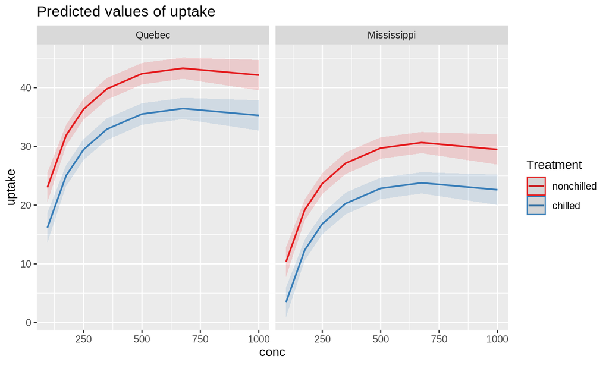

## Hay interacción?

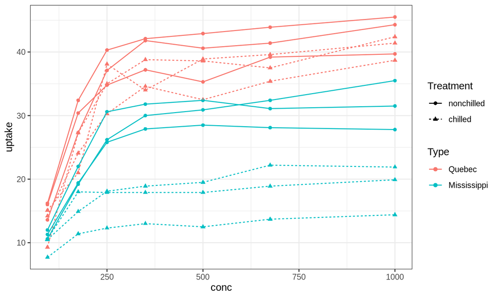

## Interaccion

```r
Model2 <- lm(uptake ~ conc + I(log(conc)) + Treatment *
    Type, data = CO2)
```

| term | estimate | std.error | statistic | p.value |
| --- | --- | --- | --- | --- |
| (Intercept) | -57.247 | 8.427 | -6.793 | 0.000 |
| conc | -0.025 | 0.004 | -5.624 | 0.000 |
| I(log(conc)) | 17.789 | 1.752 | 10.154 | 0.000 |
| Treatmentchilled | -3.581 | 1.223 | -2.929 | 0.004 |
| TypeMississippi | -9.381 | 1.223 | -7.673 | 0.000 |
| Treatmentchilled:TypeMississippi | -6.557 | 1.729 | -3.792 | 0.000 |

## Veamos

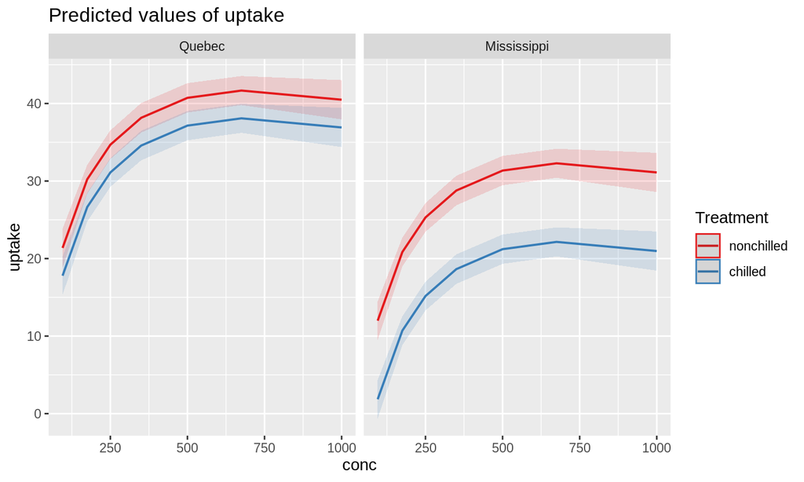